| title: “Índice Global y Local de Moran en Variación de la Especialización Relativa en Servicios Empresariales e Industria (Papeles de trabajo)” |
| --- |
| author: “Nicolás Gottig” |
| date: “2023-09-22” |
| output: |
| pdf_document: |
| latex_engine: xelatex |
| template: template.tex |

```r
library(ggtext)
library(showtext)
library(ggplot2)
showtext_auto()
font_add_google(name="Noto Sans", family = "noto")
theme_set(theme_bw(base_family = "noto"))
```

## Análisis de matriz de especialización relativa

Los datos para el cálculo de la matriz se encuentran en el archivo “matriz-especializacion-complleta.txt”. Dicho archivo contiene, para cada año, el cálculo de la especialización relativa por departamento y rama agregada según criterio del MOP. A partir de esto, se desea estudiar la evolución de la especialización relativa en el sector manufacturero y en el sector de servicios empresariales por año:

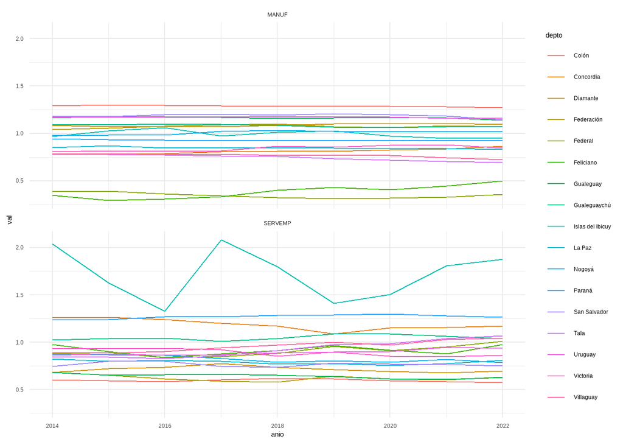

```r
library(tidyverse)
especializacion <- read_delim("matriz-especializacion-completa.txt", delim = "\t")

especializacion %>%
  select(MANUF, SERVEMP, anio, depto) %>%
  pivot_longer(-c(anio, depto), values_to = "val", names_to = "name") %>%
  ggplot() +
  aes(x = anio, y = val, col = depto) +
  geom_line() +
  theme_minimal() +
  facet_wrap(~name, nrow = 2)
```

Se puede observar que Islas del Ibicuy presenta un comportamiento normal en la especialización de la industria manufacturera, pero presenta grandes oscilaciones en la industria de servicios empresariales; casi duplicando, en ciertos años, su participación relativa en el sector. Por lo tanto, se decide excluirla del análisis posterior y estudiarla de forma individual. Sin este departamento, la evolución de los sectores en cada departamento se da de la siguiente forma:

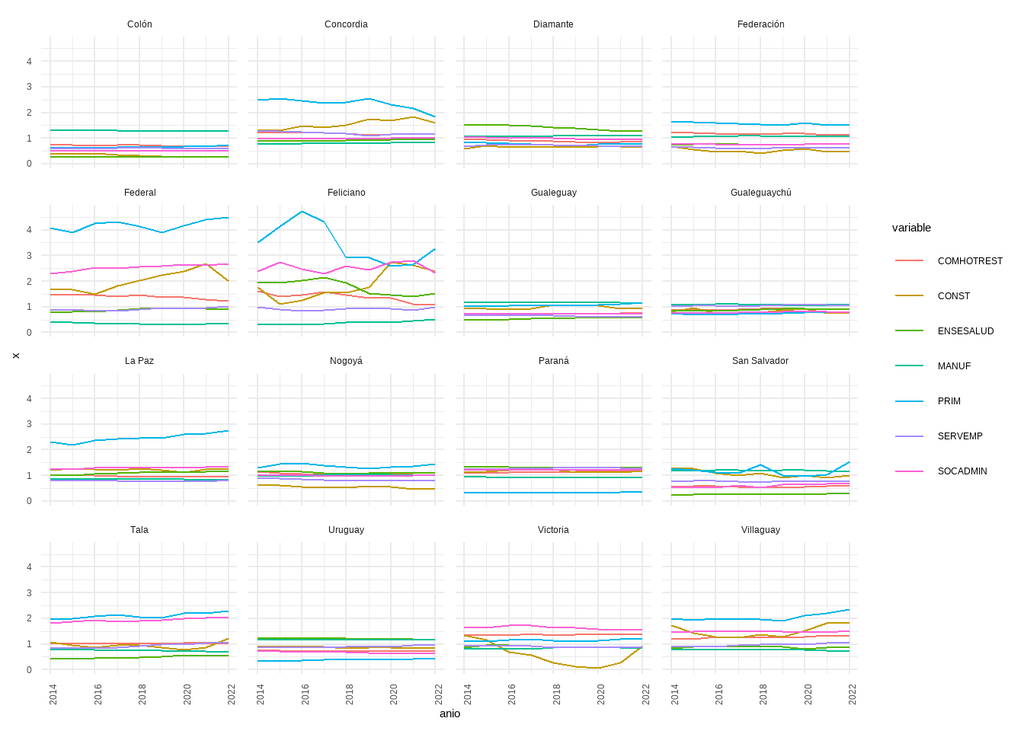

```r
especializacion  <- read_delim("matriz-especializacion-sinIslas.txt", delim = "\t")


especializacion %>%
  pivot_longer(-c(anio, depto), names_to = "variable", values_to = "x") %>%
  ggplot() +
  aes(x = anio, y = x, col = variable) +
  geom_line() +
  facet_wrap(~depto) +
  theme_minimal() +
  theme(axis.text.x = element_text(angle = 90))
```

Sin Islas del ibicuy, la tasa de variación en la especialización relativa en la provincia queda de la siguiente manera:

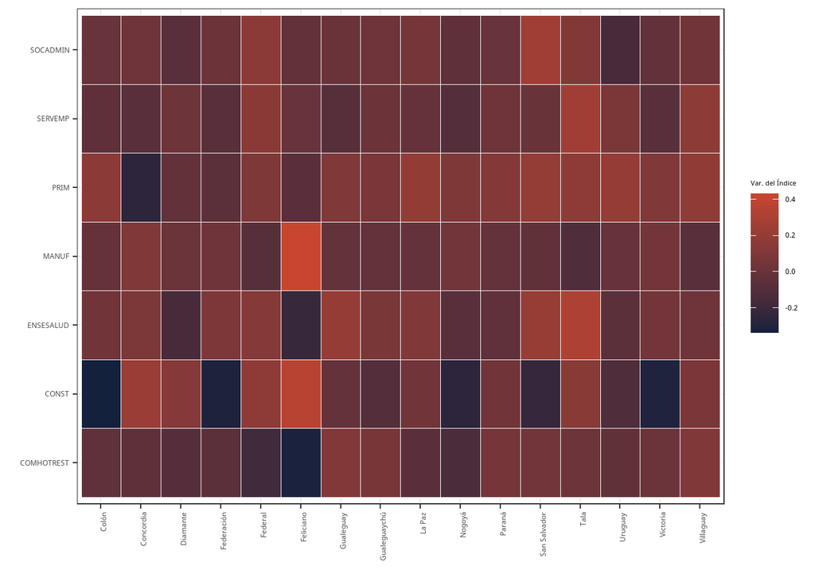

```r
especializacion  <- read_delim("matriz-especializacion-sinIslas.txt", delim = "\t")
esp2014 <- especializacion %>%
  filter(anio == 2014) %>%
  select(-anio)

esp2022 <- especializacion %>%
  filter(anio == 2022) %>%
  select(-anio)

varesp <- (esp2022[2:8] - esp2014[2:8]) / esp2014[2:8]

rownames(varesp) <- esp2014$depto

varesp %>%
  mutate(depto = rownames(.)) %>%
  pivot_longer(-depto, names_to = "variab", values_to = "valor") %>%
  ggplot() +
  aes(x = depto, y = variab, fill = valor) +
  geom_tile(colour = "white") +
  scale_fill_gradient(low="#14213d", high="#C84630")+
  theme(axis.text.x = element_text(angle = 90, hjust = 1),
        legend.title=element_text(size=8)) +
  labs(fill = "Var. del Índice" ) +
  xlab("") +
  ylab("")
```

## Caracterización de los perfiles productivos en las provincias según especialización relativa

Para la caracterización de las unidades bajo estudio se utilizan proyecciones multivariadas en las variables que recogen la especialización de un sector en cada unidad. Las dos primeras proyecciones explican casi el 80 % de la variabilidad total, por lo que se utilizarán sólo esos para el análisis.

### Correlación entre los sectores

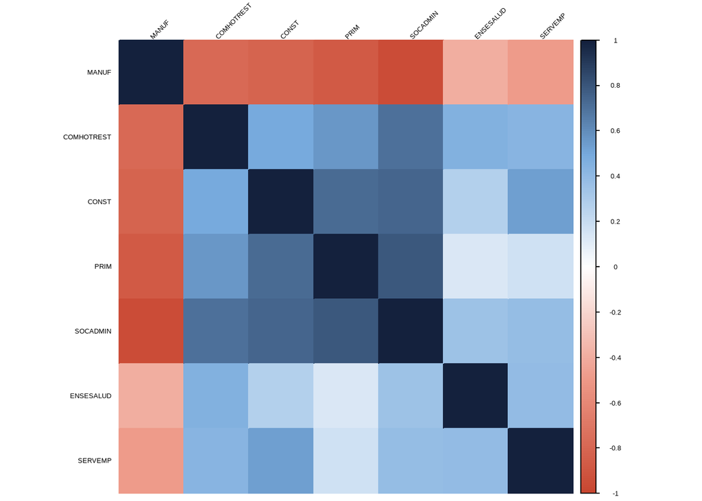

```r
# Analisis de componentes principales a tres niveles <------------------------<<<<<

# Departamentos ordenados según especialización relativa en ambos periodos
esp2014$depto <- rownames(varesp)
esp2014$anio <- 2014
esp2022$depto <- rownames(varesp)
esp2022$anio <- 2022

esp <- bind_rows(esp2014, esp2022)

esp <- esp %>%
  mutate(unid = paste0(substr(esp$depto, 0, 3), substr(esp$depto, nchar(esp$depto), nchar(esp$depto)),".",
                       substr(esp$anio, 3, 4))) %>%
  data.frame()

rownames(esp) <- esp$unid

esp <- esp %>%
  select_if(is.numeric) %>%
  select(-anio)

# Correlacion

col <- colorRampPalette(c("#C84630", "#EE9988", "#FFFFFF", "#77AADD", "#14213d"))

corrplot::corrplot(cor(esp),
                   method = "color",
                   order="hclust",
                   col=col(200),
                   tl.col="black",
                   tl.srt=45,
                   tl.cex = 0.8)
```

### Análisis de componentes

```r
pca <- FactoMineR::PCA(esp, scale.unit = "TRUE")
```

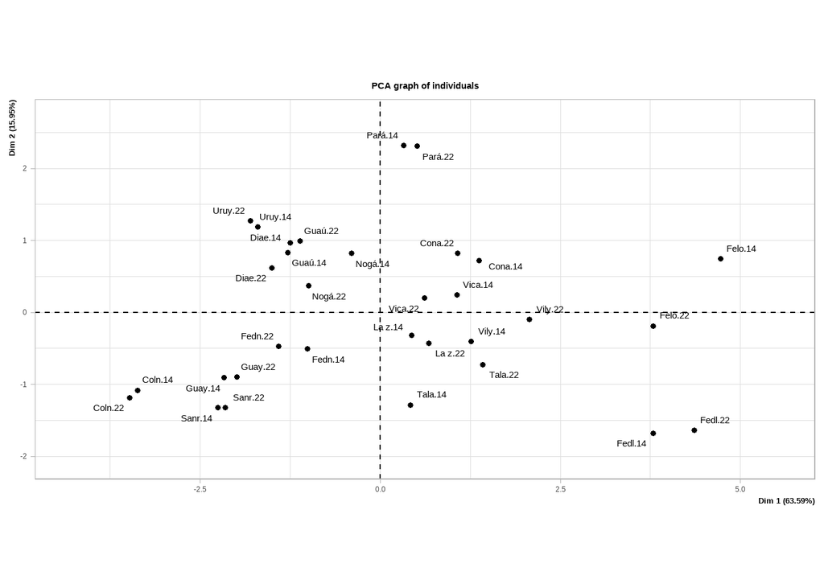

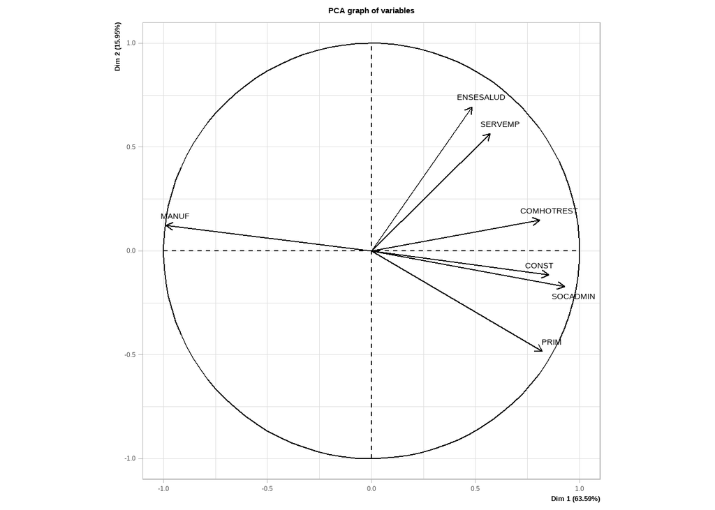

```r
pca$eig
```

```
##         eigenvalue percentage of variance cumulative percentage of variance
## comp 1 4.451424307            63.59177582                          63.59178
## comp 2 1.116454585            15.94935122                          79.54113
## comp 3 0.691674922             9.88107032                          89.42220
## comp 4 0.431817947             6.16882782                          95.59103
## comp 5 0.163282000             2.33260000                          97.92363
## comp 6 0.143040750             2.04343929                          99.96706
## comp 7 0.002305488             0.03293554                         100.00000
```

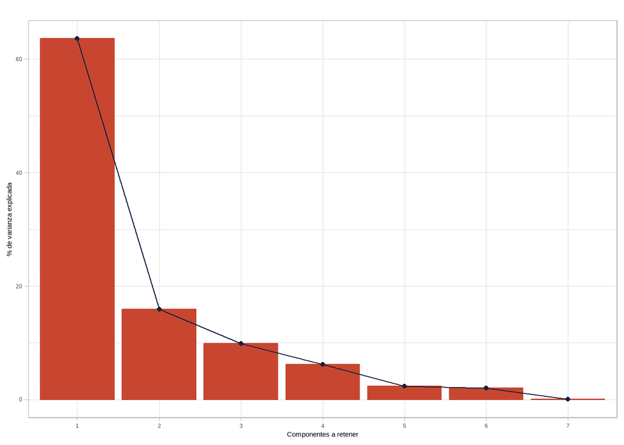

```r
factoextra::fviz_screeplot(pca, barfill ="#C84630", linecolor = "#14213d", barcolor = "#C84630") +
  ggtitle("Contribución de las dimensiones") +
  theme_light() +
  xlab("Componentes a retener") +
  ylab("% de varianza explicada") +
  labs(title = "")
```

```r
pca$var$cor
```

```
##                 Dim.1      Dim.2       Dim.3        Dim.4       Dim.5
## COMHOTREST  0.8084898  0.1480187 -0.27280988 -0.467335459  0.15745310
## CONST       0.8518563 -0.1159551  0.33036789  0.281669494  0.17571743
## ENSESALUD   0.4832624  0.6941257 -0.42133953  0.323968555  0.02289182
## MANUF      -0.9880029  0.1229367  0.03619326  0.024717743  0.06414045
## PRIM        0.8218447 -0.4840926 -0.06711304  0.096257846  0.10139481
## SERVEMP     0.5712140  0.5657068  0.56204559 -0.138587383 -0.05199131
## SOCADMIN    0.9277408 -0.1726432 -0.09418274  0.006259768 -0.29998644
```

[output not shown]

El gráfico de cargas representa la asociación de variables; en este sentido, se puede observar que un crecimiento (variación) en la especialización relativa de la manufactura está asociada a una reducción de la especialización en el resto de los sectores. Por otro lado, los aumentos en la especialización en enseñanza y salud están asociados a incrementos en la especialización del agregado “servicios empresariales”. Lo mismo, pero en menor medida, sucede con la especialización del sector primario, el agregado de servicios sociales y administración pública y construcción.

Como se informó en párrafos anteriores, las dos primeras proyecciones conservan el 79.5 % de la variabilidad orignal del conjunto de datos. Por lo que se realizará la proyección sobre estos dos ejes:

- Valores altos del **primer eje** muestra a los departamentos que tienen alta especialización relativa en el agregado de servicios sociales y administración pública, construcción y materia prima. A su vez, estos departamentos tienen los menores índices de especialización en manufactura.
- Valores altos del **segundo eje** expone a los departamentos con una fuerte especialización relativa en el agregado de enseñanza y salud y que, a su vez, presentan una menor especialización relativa en, principalmente, producción de materia prima.

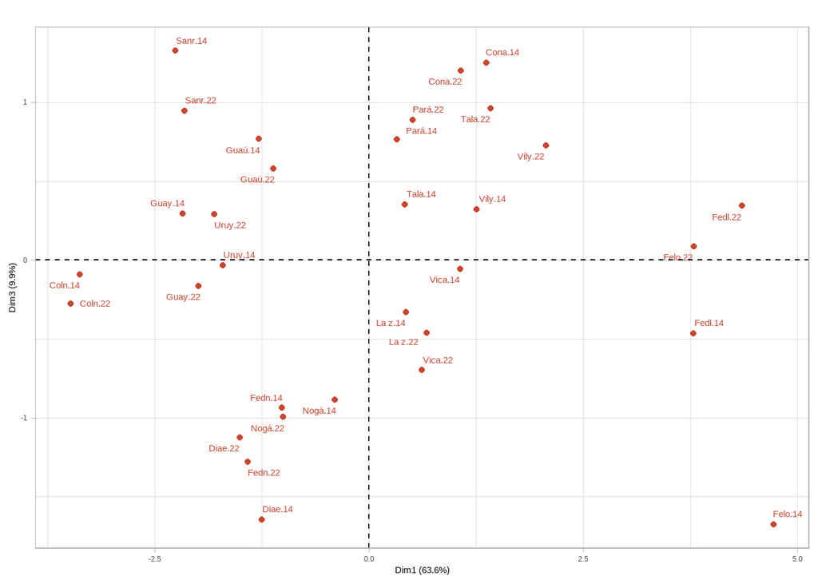

```r
factoextra::fviz_pca_ind(pca,
                         geom = c("point", "text"),
                         repel = TRUE,
                         axes = c(1,3),
                         col.ind = "#C84630") +
  labs(title ="") +
  theme_light()
```

# Autocorrelación espacial del crecimiento en servicios y manufactura

El último objetivo del artículo es evaluar la presencia de correlación espacial en el crecimiento de los sectores de interés. Es decir, si el crecimiento en estos sectores fue de forma aleatoria en el espacio o si existen aglomeraciones de crecimiento. Para esto, se calcula el Indice Global y Local de Moran, y se traducen los resultados en un *box-map*, con el objetivo de identificar *hot-spots* o puntos de concentración en el crecimiento.

## Indice global y local

En primer lugar, se seleccionan las variables y se georeferencian en la provincia:

```r
library(sf)
library(spdep)
library(tmap)

shape <- rgdal::readOGR(dsn = "mapa/pxdptodatosok.shp", verbose = FALSE)
shapeData <- sp::spTransform(shape, sp::CRS("+proj=longlat +datum=WGS84 +no_defs"))
shapeData <- sf::st_as_sf(shapeData, wkt = 'polygons', crs = st_crs(4326)) # make sf
shapeData <- rmapshaper::ms_simplify(shapeData, keep = 0.01, keep_shapes = TRUE) %>%
  filter(provincia == "Entre Ríos")

varesp$departamen <- rownames(varesp[2])
varesp$departamen <- gsub("\\.", " ", varesp$departamen)
mapdata <- sp::merge(x = shapeData, y = varesp, by = "departamen")
```

Se estudia la distribución de las variaciones para ambos sectores:

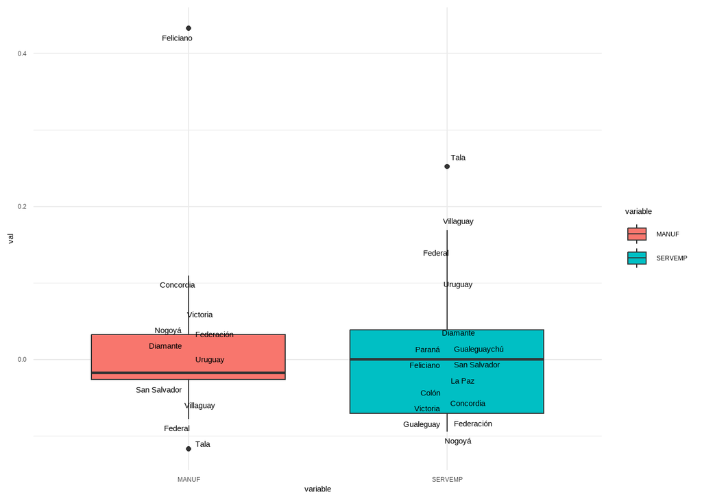

```r
mapdata %>%
  data.frame() %>%
  select(MANUF, SERVEMP, departamen) %>%
  pivot_longer(-departamen, names_to = "variable", values_to = "val") %>%
  ggplot() +
  aes(y = val, x = variable, fill = variable) +
  geom_boxplot() +
  ggrepel::geom_text_repel(aes(y = val, x = variable, label = departamen)) +
  theme_minimal()
```

Ahora, se calcula el Indice global de moran considerando a los vecinos aquellos que poseen contiguedad geográfica alrededor de cada departamento. En la literatura esto se conoce como *queen* en relación a los posibles movimientos de la reina en el ajedréz.

## Indicadores para el Índice global y local de servicios

```r
# Definición de vecinos
nb <- poly2nb(mapdata, queen=TRUE)

# Asignar peso a los vecinos
lw <- nb2listw(nb, style="W", zero.policy=TRUE)

# Analisis con pesos rezagados
per.lag <- lag.listw(lw, mapdata$SERVEMP)
per.lag
```

```
##  [1]  0.046795274  0.008238831 -0.048286517  0.026921062  0.001628460
##  [6]  0.020321219  0.024778970  0.086829440  0.085515845  0.052361933
## [11]  0.020268020  0.051339226  0.019467884  0.097723693 -0.050169080
## [16]  0.044957478
```

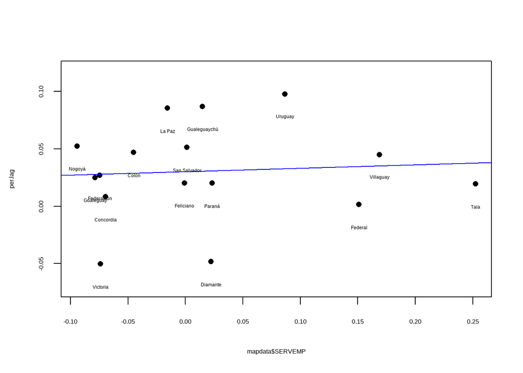

```r
plot(per.lag ~ mapdata$SERVEMP, pch=16, asp=1)
text(varesp$SERVEMP, (per.lag-0.02), labels=varesp$departamen, cex =0.75)
M1 <- lm(per.lag ~ varesp$SERVEMP)
abline(M1, col="blue")
```

```r
coef(M1)[2]
```

```
## varesp$SERVEMP
##     0.02985622
```

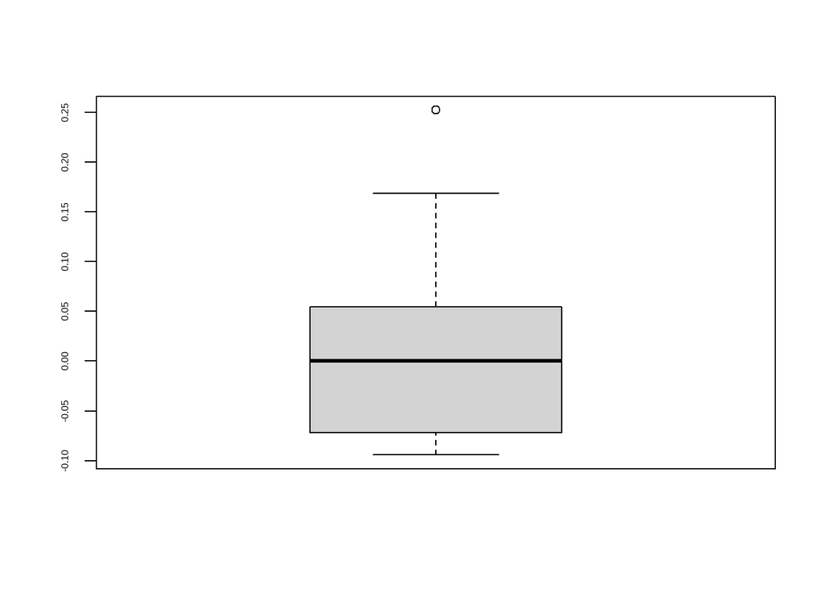

```r
# Analisis univariado del sector de servicios empresariales (esta sin islas)
boxplot(mapdata$SERVEMP)
```

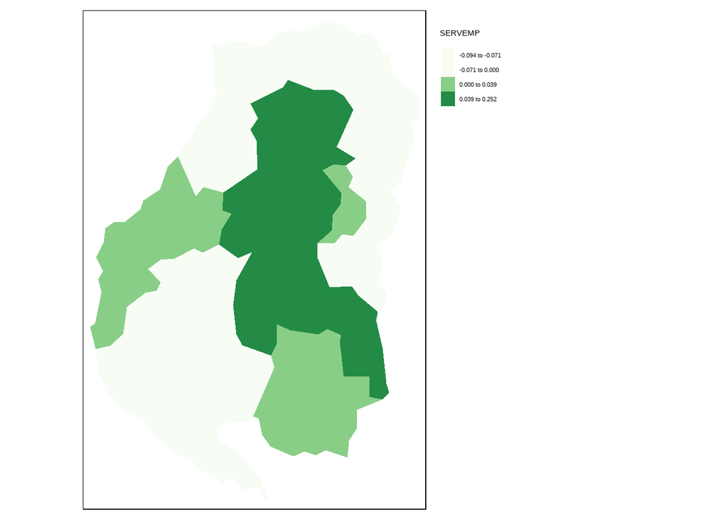

```r
# Mapa
tm_shape(mapdata) + tm_fill(col="SERVEMP",
                            style="quantile",
                            n=4,
                            palette="Greens") +
  tm_legend(outside=TRUE)
```

```r
# Definición de vecinos
nb <- poly2nb(mapdata, queen=TRUE)

# Asignar peso a los vecinos
lw <- nb2listw(nb, style="W", zero.policy=TRUE)

# Analisis con pesos rezagados
per.lag <- lag.listw(lw, mapdata$SERVEMP)
per.lag
```

```
##  [1]  0.046795274  0.008238831 -0.048286517  0.026921062  0.001628460
##  [6]  0.020321219  0.024778970  0.086829440  0.085515845  0.052361933
## [11]  0.020268020  0.051339226  0.019467884  0.097723693 -0.050169080
## [16]  0.044957478
```

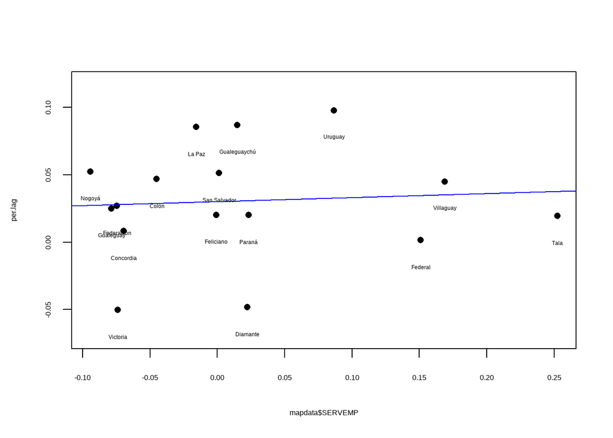

```r
plot(per.lag ~ mapdata$SERVEMP, pch=16, asp=1)
text(varesp$SERVEMP, (per.lag-0.02), labels=mapdata$departamen, cex =0.75)
M1 <- lm(per.lag ~ varesp$SERVEMP)
abline(M1, col="blue")
```

```r
coef(M1)[2]
```

```
## varesp$SERVEMP
##     0.02985622
```

```r
# Indice global y local
moran.test(mapdata$SERVEMP,lw, alternative="greater")
```

```
##
##  Moran I test under randomisation
##
## data:  mapdata$SERVEMP
## weights: lw
##
## Moran I statistic standard deviate = 0.6615, p-value = 0.2541
## alternative hypothesis: greater
## sample estimates:
## Moran I statistic       Expectation          Variance
##        0.02985622       -0.06666667        0.02129140
```

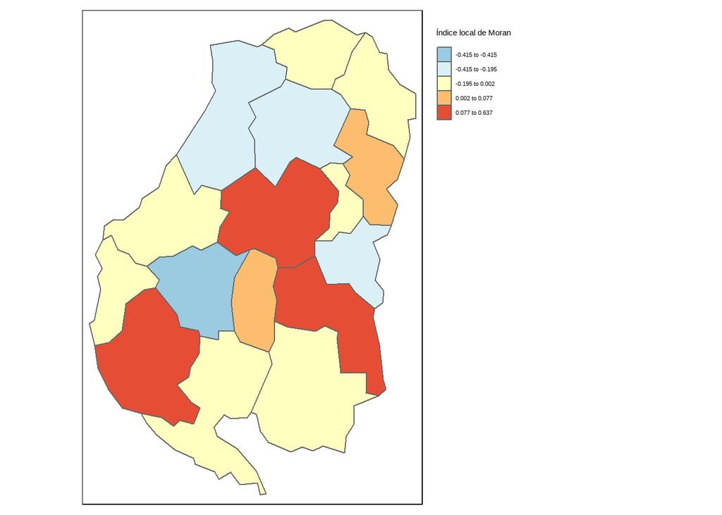

```r
moranlocal <- localmoran(mapdata$SERVEMP, lw) %>%
  data.frame()

# Almaceno en un objeto y grafico box map
mapdata$localmoran <- moranlocal$Ii

# Grafico
tm_shape(mapdata) +
  tm_borders() +  # Agregar bordes de las áreas
  tm_fill(col = "localmoran", style = "jenks", palette = "-RdYlBu", title = "Índice local de Moran") +  # Colorear por índices locales de Moran
  tm_layout(legend.outside = TRUE)  # Mostrar leyenda fuera del mapa
```

## Indicadores para el Índice global y local de industria

```r
# Definición de vecinos
nb <- poly2nb(mapdata, queen=TRUE)

# Asignar peso a los vecinos
lw <- nb2listw(nb, style="W", zero.policy=TRUE)

# Analisis con pesos rezagados
per.lag <- lag.listw(lw, mapdata$MANUF)
per.lag
```

```
##  [1] -0.000875881 -0.025263833  0.023761531  0.154839238  0.073496335
##  [6] -0.024018797 -0.012627372 -0.047986728  0.066071023 -0.028530699
## [11] -0.010108383 -0.013990355 -0.015704571 -0.057062009  0.011016939
## [16] -0.031346000
```

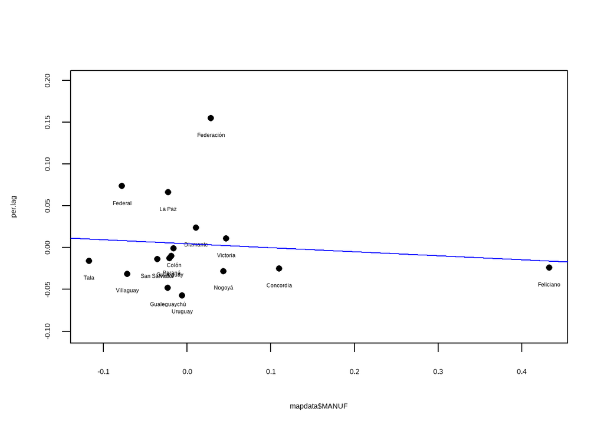

```r
plot(per.lag ~ mapdata$MANUF, pch=16, asp=1)
text(varesp$MANUF, (per.lag-0.02), labels=varesp$departamen, cex =0.75)
M1 <- lm(per.lag ~ varesp$MANUF)
abline(M1, col="blue")
```

```r
coef(M1)[2]
```

```
## varesp$MANUF
##  -0.04788988
```

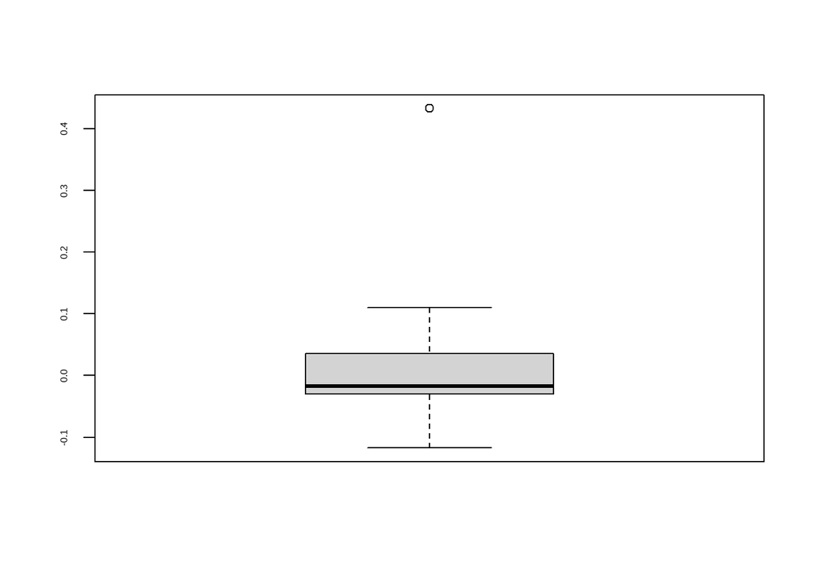

```r
# Analisis univariado del sector de servicios empresariales (esta sin islas)
boxplot(mapdata$MANUF)
```

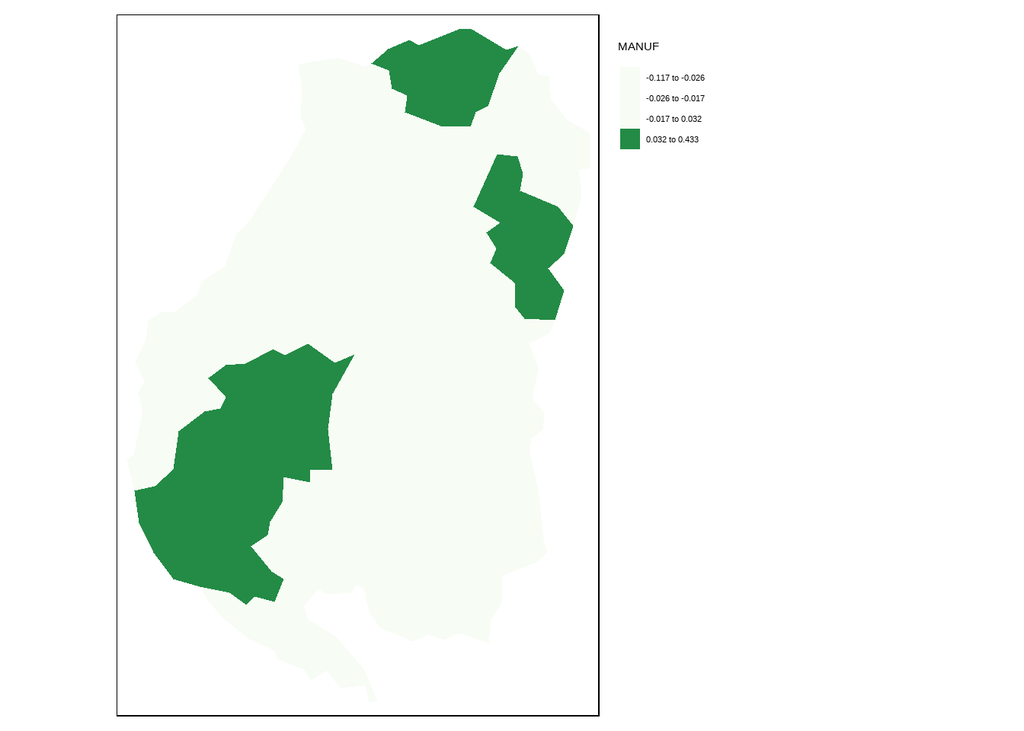

```r
# Mapa
tm_shape(mapdata) + tm_fill(col="MANUF",
                            style="quantile",
                            n=4,
                            palette="Greens") +
  tm_legend(outside=TRUE)
```

```r
# Definición de vecinos
nb <- poly2nb(mapdata, queen=TRUE)

# Asignar peso a los vecinos
lw <- nb2listw(nb, style="W", zero.policy=TRUE)

# Analisis con pesos rezagados
per.lag <- lag.listw(lw, mapdata$MANUF)
per.lag
```

```
##  [1] -0.000875881 -0.025263833  0.023761531  0.154839238  0.073496335
##  [6] -0.024018797 -0.012627372 -0.047986728  0.066071023 -0.028530699
## [11] -0.010108383 -0.013990355 -0.015704571 -0.057062009  0.011016939
## [16] -0.031346000
```

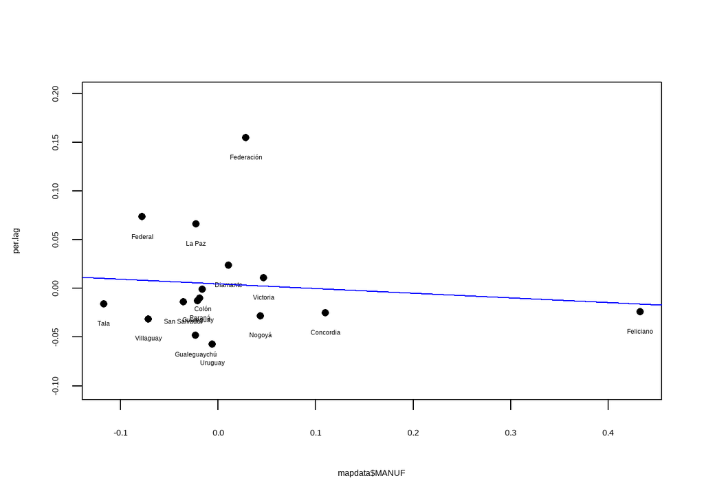

```r
plot(per.lag ~ mapdata$MANUF, pch=16, asp=1)
text(varesp$MANUF, (per.lag-0.02), labels=mapdata$departamen, cex =0.75)
M1 <- lm(per.lag ~ varesp$MANUF)
abline(M1, col="blue")
```

```r
coef(M1)[2]
```

```
## varesp$MANUF
##  -0.04788988
```

```r
# Indice global y local
moran.test(mapdata$MANUF,lw, alternative="greater")
```

```
##
##  Moran I test under randomisation
##
## data:  mapdata$MANUF
## weights: lw
##
## Moran I statistic standard deviate = 0.19485, p-value = 0.4228
## alternative hypothesis: greater
## sample estimates:
## Moran I statistic       Expectation          Variance
##      -0.047889881      -0.066666667       0.009286651
```

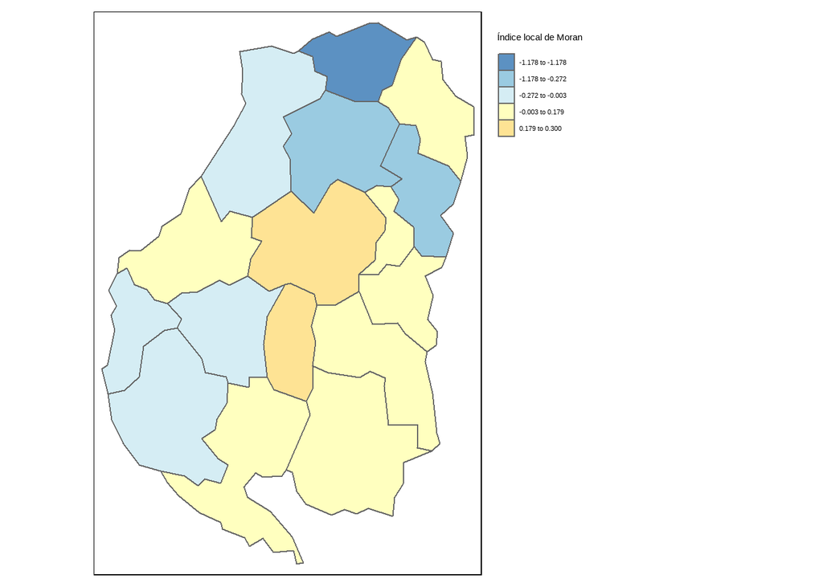

```r
moranlocal <- localmoran(mapdata$MANUF, lw) %>%
  data.frame()

# Almaceno en un objeto y grafico box map
mapdata$localmoran <- moranlocal$Ii

# Grafico
tm_shape(mapdata) +
  tm_borders() +  # Agregar bordes de las áreas
  tm_fill(col = "localmoran", style = "jenks", palette = "-RdYlBu", title = "Índice local de Moran") +  # Colorear por índices locales de Moran
  tm_layout(legend.outside = TRUE)  # Mostrar leyenda fuera del mapa
```